# Using the lifetable package

John Fox

2025-02-02

The *lifetable* package contains two user functions: `mortalityRates()`, which computes age-specific mortality rates from data on population and deaths; and `lifetable()`, which computes a life table from age-specific mortality rates.

## Calculating age-specific mortality rates

Data on deaths and population are typically recorded in single years of age or in age groups (of 5 years, for example). The age-specific mortality rate at a specific age or in a specific age group is defined as the number of individuals at that age, or in that age group, at the beginning of a calendar year who died during the year divided by the total population at that age, or in that age group, at the beginning of the year. Deaths are thus determined from vital statistics recorded over the course of the year, while population is typically measured (or estimated) on a particular date, usually July 1, the middle of the year.

Let $P_x$ represent the number of individuals at specific age $x$ on the date of measurement, and let $D_x$ represent the number of deaths recorded during the course of the year for individuals of age $x$ on January 1. Assuming that deaths occur evenly during the year and that population is measured on July 1, the age-$x$ population on January 1 is approximately $P_x + \frac{1}{2}D_x$, and thus the one-year age-specific mortality rate at age $x$ is
$$q^*_x = \frac{D_x}{P_x + \frac{1}{2}D_x}$$
If $x$ is an age interval—say a 5-year interval, such as ages 40 to 44—then $q^*_x$ represents the proportion of individuals in the age interval at the start of the year who die during the year; this is distinct from the proportion $q_x$ alive at the start of age group $x$ (e.g., age 40) who would die in a 5-year period (e.g., before age 45). For single years of age, $q^*_x = q_x$. More on this point in the next section.

The data frame `CanadaDeaths2023` in the **lifetable** package has data on deaths and mid-year population for males and females in Canada in 2023, reported in 5-year age groups:[^1]

```r
library("lifetable")
CanadaDeaths2023
```

```
#>    start end population.female population.male deaths.female deaths.male
#> 1      0   4            914872          960210           849        1105
#> 2      5   9           1034125         1088689            98          98
#> 3     10  14           1063378         1125824           121         145
#> 4     15  19           1080547         1150565           284         523
#> 5     20  24           1241956         1354011           523         991
#> 6     25  29           1391946         1517489           782        1603
#> 7     30  34           1456831         1532733          1023        2109
#> 8     35  39           1387063         1425708          1241        2495
#> 9     40  44           1331021         1346434          1441        2787
#> 10    45  49           1234659         1224346          1917        3224
#> 11    50  54           1229275         1202081          2810        4772
#> 12    55  59           1288417         1261813          4588        7687
#> 13    60  64           1358461         1323303          7591       11936
#> 14    65  69           1225282         1154724         10760       15820
#> 15    70  74            998233          912977         13863       19227
#> 16    75  79            772554          685170         18353       23007
#> 17    80  84            507257          409343         21182       23912
#> 18    85  89            319764          218994         24885       23276
#> 19    90  94            174701           90629         25518       17556
#> 20    95  99             56801           19805         14659        6271
#> 21   100 Inf              9364            2129          4163        1020
```

Note that the last age interval (`100`–`Inf`) is open-ended.

From data like these, `mortalityRates()` can calculate age-specific mortality rates. For example, for females:

```r
(CanMort23 <- with(CanadaDeaths2023,
                   mortalityRates(population = population.female,
                                  deaths = deaths.female,
                                  start = start, end = end,
                                  day = "2023-07-01")))
```

```
#>    start end mortality.rate
#> 1      0   4  0.00092756946
#> 2      5   9  0.00009476163
#> 3     10  14  0.00011378187
#> 4     15  19  0.00026279540
#> 5     20  24  0.00042102152
#> 6     25  29  0.00056164607
#> 7     30  34  0.00070196332
#> 8     35  39  0.00089429724
#> 9     40  44  0.00108204343
#> 10    45  49  0.00155145429
#> 11    50  54  0.00228329768
#> 12    55  59  0.00355464728
#> 13    60  64  0.00557241455
#> 14    65  69  0.00874336648
#> 15    70  74  0.01379203296
#> 16    75  79  0.02347815554
#> 17    80  84  0.04090618666
#> 18    85  89  0.07491591468
#> 19    90  94  0.13615042834
#> 20    95  99  0.22865238113
#> 21   100 Inf  0.36390505053
```

Along with `population` and `deaths`, the `start` and `end` of each age interval is supplied, and `day` gives the date at which population is measured. The `day` can be given in several forms (here, `"yyyy-mm-dd"`l), including the numeric day of year, which defaults to `182` (and is equivalent to July 1 for a non-leap-year). See `?mortalityRates` for some additional details.

A slight wrinkle is that the first and second years of age are treated specially, if data on single years of age are supplied for these years. It is assumed that `a0` and `a1` proportion of deaths at ages 0 and 1, respectively, occur during the first half of the year, where the argument `a0` to `mortalityRates()` defaults to `0.7`, and `a1` defaults to `0.6`. If population isn’t measured mid-year, then a crude linear interpolation is done based on the date of measurement.

The `lifetable` package includes two data sets with mortality rates pre-computed, both for Canada in 2022–2023:

```r
CanadaMortality # 5-year age groups after age 4
```

```
#>    start end q.female q.male
#> 1      0   0   0.0042 0.0051
#> 2      1   4   0.0002 0.0002
#> 3      5   9   0.0001 0.0001
#> 4     10  14   0.0001 0.0001
#> 5     15  19   0.0003 0.0005
#> 6     20  24   0.0004 0.0007
#> 7     25  29   0.0006 0.0011
#> 8     30  34   0.0007 0.0014
#> 9     35  39   0.0009 0.0017
#> 10    40  44   0.0011 0.0021
#> 11    45  49   0.0016 0.0026
#> 12    50  54   0.0023 0.0040
#> 13    55  59   0.0036 0.0061
#> 14    60  64   0.0056 0.0090
#> 15    65  69   0.0088 0.0137
#> 16    70  74   0.0139 0.0210
#> 17    75  79   0.0238 0.0335
#> 18    80  84   0.0418 0.0584
#> 19    85  89   0.0779 0.1062
#> 20    90 Inf   0.1840 0.2208
```

```r
head(CanadaMortalitySingleYear) # single-year data
```

```
#>   age q.female  q.male
#> 1   0  0.00406 0.00477
#> 2   1  0.00023 0.00030
#> 3   2  0.00017 0.00022
#> 4   3  0.00014 0.00017
#> 5   4  0.00011 0.00013
#> 6   5  0.00010 0.00011
```

```r
tail(CanadaMortalitySingleYear) # single-year data
```

```
#>     age q.female  q.male
#> 105 104  0.40262 0.44999
#> 106 105  0.42511 0.46987
#> 107 106  0.44672 0.48866
#> 108 107  0.46732 0.50626
#> 109 108  0.48676 0.52263
#> 110 109  0.50496 0.53776
```

## Constructing life tables

The description is this section and the calculations performed by the `lifetable()` function are based on Barclay (1958). The arguments of the `lifetable()` function are

```r
args(lifetable)
```

```
#> function (q, start = 0:(n - 1), end = start, radix = 100000,
#>     a0 = 0.7, a1 = 0.6, annual = TRUE)
#> NULL
```

where:

- `q` are age-specific mortality rates;
- `start` and `end` give the age at the beginning and end of each interval, where the default is single years of age starting at age 0 (and where `n` represents the number of values in `q`);
- `radix` is the number of individuals in the *synthetic cohort*[^2] for which the life table is computed, defaulting to 100,000;
- `a0` and `a1` are the proportion of deaths between ages 0 and 1 and between 1 and 2 assumed to occur by the middle of the year, defaulting to 0.7 and 0.6, respectively (see below); for ages 2 and above, deaths are assumed to be evenly distributed throughout the year, and so this proportion is 0.5; and
- `annual`, defaulting to `TRUE`, indicates whether the values of `q` are to be interpreted as annual mortality rates (i.e., $q_x^*$s).

### Single-year life tables

I’ll begin with a single-year life table, where $q_x^* = q_x$, because that’s the simplest case:

```r
(lt.female <- lifetable(q = CanadaMortalitySingleYear$q.female))
```

```
#>             l[x] d[x]    p[x]    q[x]  L[x]    T[x]      e[x]
#> 0 years   100000  406 0.99594 0.00406 99716 8378799 83.787990
#> 1 year     99594   23 0.99977 0.00023 99580 8279083 83.128331
#> 2 years    99571   17 0.99983 0.00017 99563 8179503 82.147443
#> 3 years    99554   14 0.99986 0.00014 99547 8079940 81.161380
#> 4 years    99540   11 0.99989 0.00011 99535 7980393 80.172725
#> 5 years    99529   10 0.99990 0.00010 99524 7880858 79.181525
#> 6 years    99519    9 0.99991 0.00009 99515 7781334 78.189431
#> 7 years    99510    8 0.99992 0.00008 99506 7681819 77.196453
#> 8 years    99502    8 0.99992 0.00008 99498 7582313 76.202619
#> 9 years    99494    8 0.99992 0.00008 99490 7482815 75.208706
#> 10 years   99486    8 0.99992 0.00008 99482 7383325 74.214714
#> 11 years   99478    9 0.99991 0.00009 99474 7283843 73.220642
#> 12 years   99469   10 0.99990 0.00010 99464 7184369 72.227217
#> 13 years   99459   12 0.99988 0.00012 99453 7084905 71.234428
```

[output cut: 96 more lines]

The only required argument for a single-year life table is `q`.

$q_x$ is the key column in the life table in that all other columns can be computed from it (and the radix), and it is the link between mortality data and the life table. This description of the columns of the life table also suggests how to compute a life table given age-specific mortality rates $q_x$:

The following graph shows the percentage of the synthetic cohort surviving at each age, based on the single-year life table for females computed above and on a similar life table for males:

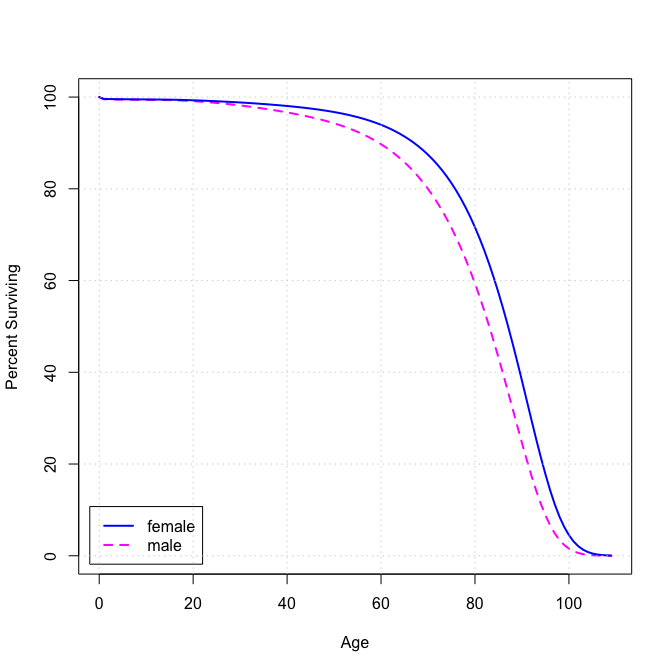

Percent surviving by age and sex, based on age-specific mortality rates for Canada in 2022–2023

```r
lt.male <- lifetable(q = CanadaMortalitySingleYear$q.male)
plot(0:109, lt.male[, "l[x]"]/1000, type="l", col="magenta",
      lwd=2, lty=2, xlab="Age", ylab="Percent Surviving")
 lines(0:109, lt.female[, "l[x]"]/1000, type="l", col="blue",
       lty=1, lwd=2)
 legend("bottomleft", inset=0.02, legend=c("female", "male"),
        lty=1:2, lwd=2, col=c("blue", "magenta"))
 grid()
```

### Life tables for age groups

I earlier used the `mortalityRates()` function to calculate age-specific mortality rates for females in Canada, based on death and population data for 2023:

```r
CanMort23
```

```
#>    start end mortality.rate
#> 1      0   4  0.00092756946
#> 2      5   9  0.00009476163
#> 3     10  14  0.00011378187
#> 4     15  19  0.00026279540
#> 5     20  24  0.00042102152
#> 6     25  29  0.00056164607
#> 7     30  34  0.00070196332
#> 8     35  39  0.00089429724
#> 9     40  44  0.00108204343
#> 10    45  49  0.00155145429
#> 11    50  54  0.00228329768
#> 12    55  59  0.00355464728
#> 13    60  64  0.00557241455
#> 14    65  69  0.00874336648
#> 15    70  74  0.01379203296
#> 16    75  79  0.02347815554
#> 17    80  84  0.04090618666
#> 18    85  89  0.07491591468
#> 19    90  94  0.13615042834
#> 20    95  99  0.22865238113
#> 21   100 Inf  0.36390505053
```

These annual mortality rates are for 5-year age intervals, and from the mortality rates, we can compute a life table based on the 5-year age groups:

```r
with(CanMort23,
     lifetable(q=mortality.rate, start=start, end=end))
```

```
#>                 l[x]  d[x]    p[x]    q[x]   L[x]    T[x]      e[x]
#> 0 - 4 years   100000   463 0.99537 0.00463 498840 8413525 84.135250
#> 5 - 9 years    99537    47 0.99953 0.00047 497570 7914685 79.515004
#> 10 - 14 years  99490    57 0.99943 0.00057 497310 7417115 74.551362
#> 15 - 19 years  99433   130 0.99869 0.00131 496840 6919805 69.592640
#> 20 - 24 years  99303   209 0.99790 0.00210 495995 6422965 64.680473
#> 25 - 29 years  99094   278 0.99719 0.00281 494775 5926970 59.811593
#> 30 - 34 years  98816   346 0.99650 0.00350 493215 5432195 54.972828
#> 35 - 39 years  98470   439 0.99554 0.00446 491250 4938980 50.157205
#> 40 - 44 years  98031   529 0.99460 0.00540 488830 4447730 45.370648
#> 45 - 49 years  97502   754 0.99227 0.00773 485625 3958900 40.603270
#> 50 - 54 years  96748  1099 0.98864 0.01136 480990 3473275 35.900225
#> 55 - 59 years  95649  1688 0.98235 0.01765 474025 2992285 31.284018
#> 60 - 64 years  93961  2589 0.97245 0.02755 463335 2518260 26.801120
#> 65 - 69 years  91372  3925 0.95704 0.04296 447045 2054925 22.489658
#> 70 - 74 years  87447  5866 0.93292 0.06708 422570 1607880 18.386909
#> 75 - 79 years  81581  9138 0.88799 0.11201 385060 1185310 14.529241
#> 80 - 84 years  72443 13653 0.81153 0.18847 328080  800250 11.046616
#> 85 - 89 years  58790 18960 0.67749 0.32251 246550  472170  8.031468
#> 90 - 94 years  39830 20670 0.48105 0.51895 147475  225620  5.664574
#> 95 - 99 years  19160 13928 0.27306 0.72694  60980   78145  4.078549
#> 100+ years      5232  4687 0.10414 0.89586  14440   17165  3.280772
```

The arithmetic of the life table for age groups is very similar to that of the life table for single years of age. Assuming that the input mortality rates $q_x^*$ are for annual mortality, we must first compute the age-specific mortality rate $q_x$, the conditional probability of dying between age $x$ and the start of the next age group, age $x + \Delta x$. In the single-year life table, $\Delta x = 1$, in the current example, $\Delta x = 5$, and more generally, $\Delta x$ can depend on $x$, as I’ll illustrate shortly.

Assuming that the mortality rate is constant in the age interval from $x$ to $x + \Delta x$, $q_x = 1 - (1 - q_x^*)^{\Delta x}$. Then, as before, the conditional probability of surviving to age $x + \Delta x$ is $p_x = 1 - q_x$, and the expected number of deaths in the age interval is $d_x = q_x l_x$. To get the number of person-years lived in the age interval, we need to account for the length of the interval $\Delta x$: $L_x = (l_x - 0.5 d_x) \Delta x$. Similarly, $T_x = \sum_{x' \ge x} L_{x'} + l_X \Delta x$, which assumes that those alive at the end of the life table, $l_X$, on average live $\Delta x$ more years. As before, expectation of life at each age is $e_x = T_x/l_x$.

As mentioned, $\Delta x$ can depend on $x$. For example, the `CanadaMortality` data set in the **lifetable** package contains the following age-group-specific mortality rates for males and females Canada in 2023:

```r
CanadaMortality
```

```
#>    start end q.female q.male
#> 1      0   0   0.0042 0.0051
#> 2      1   4   0.0002 0.0002
#> 3      5   9   0.0001 0.0001
#> 4     10  14   0.0001 0.0001
#> 5     15  19   0.0003 0.0005
#> 6     20  24   0.0004 0.0007
#> 7     25  29   0.0006 0.0011
#> 8     30  34   0.0007 0.0014
#> 9     35  39   0.0009 0.0017
#> 10    40  44   0.0011 0.0021
#> 11    45  49   0.0016 0.0026
#> 12    50  54   0.0023 0.0040
#> 13    55  59   0.0036 0.0061
#> 14    60  64   0.0056 0.0090
#> 15    65  69   0.0088 0.0137
#> 16    70  74   0.0139 0.0210
#> 17    75  79   0.0238 0.0335
#> 18    80  84   0.0418 0.0584
#> 19    85  89   0.0779 0.1062
#> 20    90 Inf   0.1840 0.2208
```

Here, $\Delta x$ for $x = 0$ is 1 year, for $x = 1$ is 4 years, and for $1 < x < 90$ is 5 years, with the last age group, for which $X = 90$, open-ended. Unequal age groups present no new difficulties, other than allowing $\Delta x$ to vary; for example, for males:

```r
with(CanadaMortality,
     lifetable(q=q.male, start=start, end=end))
```

```
#>                    l[x]  d[x]    p[x]    q[x]   L[x]    T[x]      e[x]
#> less than 1 year 100000   510 0.99490 0.00510  99643 7952723 79.527230
#> 1 - 4 years       99490    80 0.99920 0.00080 397800 7853080 78.933360
#> 5 - 9 years       99410    50 0.99950 0.00050 496925 7455280 74.995272
#> 10 - 14 years     99360    50 0.99950 0.00050 496675 6958355 70.031753
#> 15 - 19 years     99310   248 0.99750 0.00250 495930 6461680 65.065754
#> 20 - 24 years     99062   347 0.99650 0.00350 494445 5965750 60.222386
#> 25 - 29 years     98715   542 0.99451 0.00549 492220 5471305 55.425265
#> 30 - 34 years     98173   685 0.99302 0.00698 489150 4979085 50.717458
#> 35 - 39 years     97488   826 0.99153 0.00847 485375 4489935 46.056284
#> 40 - 44 years     96662  1011 0.98954 0.01046 480780 4004560 41.428483
#> 45 - 49 years     95651  1237 0.98707 0.01293 475165 3523780 36.839970
#> 50 - 54 years     94414  1873 0.98016 0.01984 467385 3048615 32.289862
#> 55 - 59 years     92541  2788 0.96987 0.03013 455735 2581230 27.892826
#> 60 - 64 years     89753  3967 0.95580 0.04420 438845 2125495 23.681604
#> 65 - 69 years     85786  5718 0.93335 0.06665 414635 1686650 19.661134
#> 70 - 74 years     80068  8061 0.89932 0.10068 380185 1272015 15.886684
#> 75 - 79 years     72007 11280 0.84335 0.15665 331835  891830 12.385324
#> 80 - 84 years     60727 15779 0.74017 0.25983 264190  559995  9.221516
#> 85 - 89 years     44948 19308 0.57043 0.42957 176470  295805  6.581049
#> 90+ years         25640 18275 0.28724 0.71276  82510  119335  4.654251
```

## Reference

Barclay, G. (1958). *Techniques of population analysis*. New York: Wiley.

[^1]: For the source of these data, see `?CanadaDeaths2023`, and similarly for the other data sets in the **lifetable** package.
[^2]: Although a life table can be computed for a real birth cohort (individuals born in a particular year) by following the cohort until everyone is dead, it is more common, as here, to construct the table for a synthetic cohort—an imaginary group of people who die according to current age-specific rates of mortality. Because mortality rates typically change over time, a synthetic cohort does not correspond to any real cohort.